# Canny Edge Detection for Coastline Extraction

**Student Name:** Andrés Jauch  
**Semester Term:** FS26

## Introduction & Use Case

For this second task, I'm implementing a step-by-step Canny edge detector. The goal is to extract the coastline of Hispaniola and see how the haze configurations I simulated in Task 1 affect the edge detection. Writing the steps manually helps to understand what goes on under the hood.

```python
import cv2
import numpy as np
import matplotlib.pyplot as plt
import pandas as pd
```

## Technical Implementation

### Load and prepare the image

I load the satellite image and convert it to grayscale. Since I am implementing the non-maximum suppression and hysteresis steps using Python loops, running them on the full-resolution image takes way too long. I resized the image to a width of 800 pixels so the execution finishes in a few seconds.

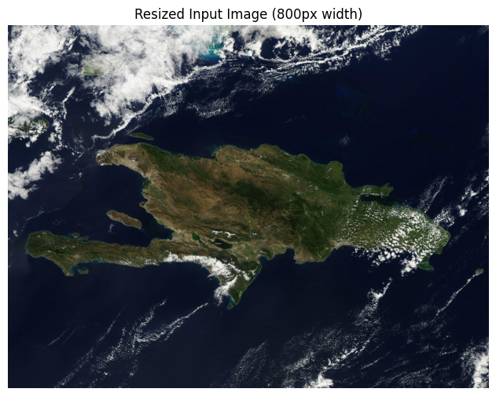

```python
# Load image
img_bgr = cv2.imread("source/satelita_hispaniola.jpg")
if img_bgr is None:
    raise FileNotFoundError("Please make sure ../source/satelita_hispaniola.jpg exists.")

# Downsample for faster loops
target_width = 800
H, W, _ = img_bgr.shape
target_height = int(target_width * H / W)
img_bgr = cv2.resize(img_bgr, (target_width, target_height), interpolation=cv2.INTER_AREA)

img_rgb = cv2.cvtColor(img_bgr, cv2.COLOR_BGR2RGB)
img_gray = cv2.cvtColor(img_bgr, cv2.COLOR_BGR2GRAY)

plt.figure(figsize=(10, 6))
plt.imshow(img_rgb)
plt.title("Resized Input Image (800px width)")
plt.axis("off")
plt.show()
```

### Smoothing (Gaussian Blur)

I apply a 5x5 Gaussian filter to smooth out noise in the grayscale image, which helps prevent false edges from showing up.

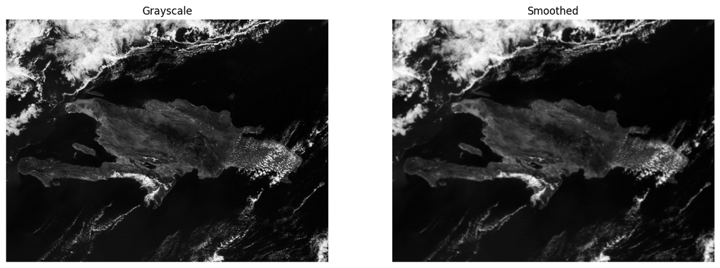

```python
gaussian_kernel = np.array([
    [1,  4,  7,  4, 1],
    [4, 16, 26, 16, 4],
    [7, 26, 41, 26, 7],
    [4, 16, 26, 16, 4],
    [1,  4,  7,  4, 1]
], dtype=np.float32) / 273.0

img_smoothed = cv2.filter2D(img_gray, -1, gaussian_kernel)

fig, axes = plt.subplots(1, 2, figsize=(15, 7))
axes[0].imshow(img_gray, cmap='gray')
axes[0].set_title("Grayscale")
axes[0].axis("off")
axes[1].imshow(img_smoothed, cmap='gray')
axes[1].set_title("Smoothed")
axes[1].axis("off")
plt.show()
```

### Gradients (Sobel Filter)

Next, I calculate the horizontal and vertical gradients (Ix and Iy) using Sobel filters. From this, I get the gradient magnitude (to see how strong the edges are) and direction (angle).

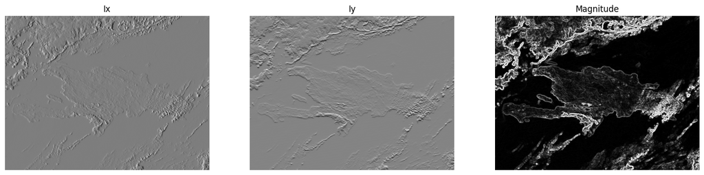

```python
Kx = np.array([[-1, 0, 1], [-2, 0, 2], [-1, 0, 1]], dtype=np.float32)
Ky = np.array([[-1, -2, -1], [ 0,  0,  0], [ 1,  2,  1]], dtype=np.float32)

Ix = cv2.filter2D(img_smoothed, cv2.CV_32F, Kx)
Iy = cv2.filter2D(img_smoothed, cv2.CV_32F, Ky)

magnitude = np.sqrt(Ix**2 + Iy**2)
direction = np.arctan2(Iy, Ix)

magnitude_normalized = np.uint8(np.clip(magnitude, 0, 255))

fig, axes = plt.subplots(1, 3, figsize=(18, 6))
axes[0].imshow(Ix, cmap='gray')
axes[0].set_title("Ix")
axes[0].axis("off")
axes[1].imshow(Iy, cmap='gray')
axes[1].set_title("Iy")
axes[1].axis("off")
axes[2].imshow(magnitude_normalized, cmap='gray')
axes[2].set_title("Magnitude")
axes[2].axis("off")
plt.show()
```

### Non-Maximum Suppression (Thinning)

The gradient map has thick edges. I will run a loop to keep only the local maximum pixels in the direction of the gradient, which thins down the edges to single-pixel lines.

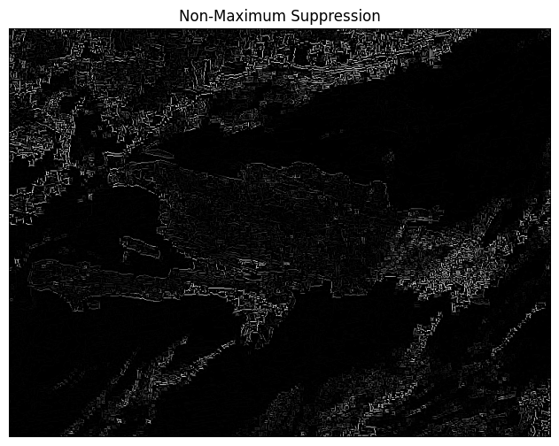

```python
def non_max_suppression(img_mag, img_dir):
    H, W = img_mag.shape
    nms_out = np.zeros((H, W), dtype=np.float32)
    angle = img_dir * 180.0 / np.pi
    angle[angle < 0] += 180

    for i in range(1, H-1):
        for j in range(1, W-1):
            q = 255
            r = 255
            # Angle 0
            if (0 <= angle[i,j] < 22.5) or (157.5 <= angle[i,j] <= 180):
                q = img_mag[i, j+1]
                r = img_mag[i, j-1]
            # Angle 45
            elif (22.5 <= angle[i,j] < 67.5):
                q = img_mag[i-1, j+1]
                r = img_mag[i+1, j-1]
            # Angle 90
            elif (67.5 <= angle[i,j] < 112.5):
                q = img_mag[i+1, j]
                r = img_mag[i-1, j]
            # Angle 135
            elif (112.5 <= angle[i,j] < 157.5):
                q = img_mag[i-1, j-1]
                r = img_mag[i+1, j+1]

            if (img_mag[i,j] >= q) and (img_mag[i,j] >= r):
                nms_out[i,j] = img_mag[i,j]
            else:
                nms_out[i,j] = 0
    return nms_out

img_nms = non_max_suppression(magnitude, direction)
img_nms_normalized = np.uint8(np.clip(img_nms, 0, 255))

plt.figure(figsize=(10, 6))
plt.imshow(img_nms_normalized, cmap='gray')
plt.title("Non-Maximum Suppression")
plt.axis("off")
plt.show()
```

### Double Thresholding and Hysteresis

Now I classify pixels into strong, weak, or non-edges based on two thresholds. Strong edges are kept. Weak edges are only kept if they connect to a strong edge. I implemented a stack based flood fill to trace these connections

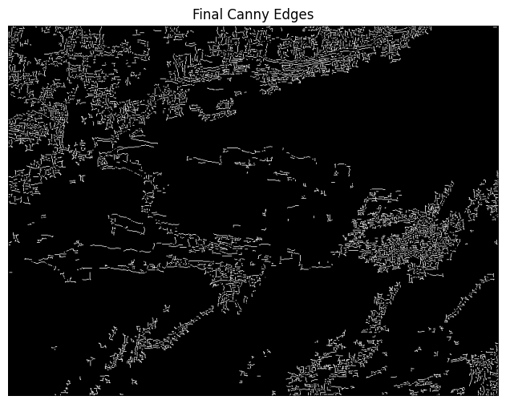

```python
def double_threshold_and_hysteresis(img, low_ratio=0.08, high_ratio=0.18):
    high_val = img.max() * high_ratio
    low_val = high_val * low_ratio

    H, W = img.shape
    res = np.zeros((H, W), dtype=np.uint8)

    weak = 100
    strong = 255

    strong_i, strong_j = np.where(img >= high_val)
    weak_i, weak_j = np.where((img >= low_val) & (img < high_val))

    res[strong_i, strong_j] = strong
    res[weak_i, weak_j] = weak

    # Trace connected edges with stack queue
    stack = list(zip(strong_i, strong_j))
    visited = np.zeros((H, W), dtype=bool)

    while stack:
        y, x = stack.pop()
        if visited[y, x]:
            continue
        visited[y, x] = True
        res[y, x] = strong

        for dy in [-1, 0, 1]:
            for dx in [-1, 0, 1]:
                ny, nx = y + dy, x + dx
                if 0 <= ny < H and 0 <= nx < W:
                    if res[ny, nx] == weak and not visited[ny, nx]:
                        stack.append((ny, nx))

    res[res == weak] = 0
    return res

final_edges = double_threshold_and_hysteresis(img_nms)

plt.figure(figsize=(10, 6))
plt.imshow(final_edges, cmap='gray')
plt.title("Final Canny Edges")
plt.axis("off")
plt.show()
```

## Comparison under Hazy Conditions

Testing on Hazy Images: Now I'll run my step-by-step Canny pipeline on the two hazy images from the first task (Light Haze and Heavy Haze) to see how the edge detection (hopefully) degrades.

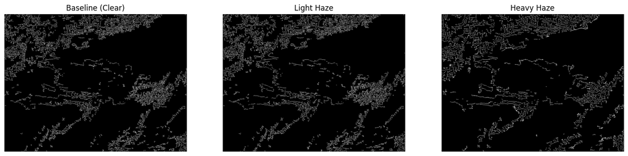

```python
def simulate_haze(image, k, alpha):
    blurred = cv2.GaussianBlur(image, (k, k), 0)
    beta = (1.0 - alpha) * 255 / 2
    return cv2.convertScaleAbs(blurred, alpha=alpha, beta=beta)

img_light_haze = simulate_haze(img_gray, k=5, alpha=0.8)
img_heavy_haze = simulate_haze(img_gray, k=11, alpha=0.5)

# Run Canny steps on light haze
Ix_light = cv2.filter2D(img_light_haze, cv2.CV_32F, Kx)
Iy_light = cv2.filter2D(img_light_haze, cv2.CV_32F, Ky)
mag_light = np.sqrt(Ix_light**2 + Iy_light**2)
dir_light = np.arctan2(Iy_light, Ix_light)
nms_light = non_max_suppression(mag_light, dir_light)
edges_light = double_threshold_and_hysteresis(nms_light)

# Run Canny steps on heavy haze
Ix_heavy = cv2.filter2D(img_heavy_haze, cv2.CV_32F, Kx)
Iy_heavy = cv2.filter2D(img_heavy_haze, cv2.CV_32F, Ky)
mag_heavy = np.sqrt(Ix_heavy**2 + Iy_heavy**2)
dir_heavy = np.arctan2(Iy_heavy, Ix_heavy)
nms_heavy = non_max_suppression(mag_heavy, dir_heavy)
edges_heavy = double_threshold_and_hysteresis(nms_heavy)

fig, axes = plt.subplots(1, 3, figsize=(18, 6))
axes[0].imshow(final_edges, cmap='gray')
axes[0].set_title("Baseline (Clear)")
axes[0].axis("off")
axes[1].imshow(edges_light, cmap='gray')
axes[1].set_title("Light Haze")
axes[1].axis("off")
axes[2].imshow(edges_heavy, cmap='gray')
axes[2].set_title("Heavy Haze")
axes[2].axis("off")
plt.show()
```

## Quantitative Evaluation

Evaluation Metric: Edge Density.

To measure the impact of haze, I'll use exactly one metric: Edge Density.

It is the percentage of edge pixels in the final binary edge image relative to the total number of pixels.

Edge Density (%) = (Edge Pixels / Total Pixels) * 100

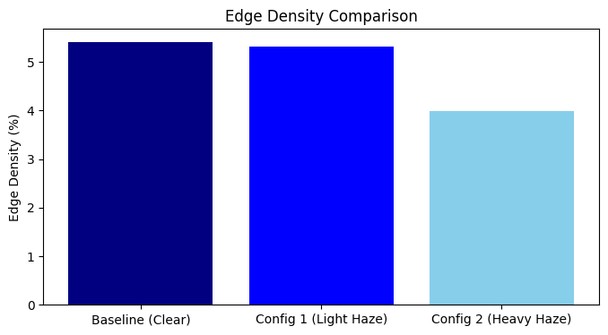

|  | Configuration | Edge Density (%) | Relative Change (%) |
| --- | --- | --- | --- |
| 0 | Baseline (Clear) | 5.406664 | 0.000000 |
| 1 | Config 1 (Light Haze) | 5.308361 | -1.818182 |
| 2 | Config 2 (Heavy Haze) | 3.982202 | -26.346411 |

```python
def calculate_edge_density(edges):
    return (np.sum(edges == 255) / edges.size) * 100.0

density_base = calculate_edge_density(final_edges)
density_light = calculate_edge_density(edges_light)
density_heavy = calculate_edge_density(edges_heavy)

# Bar chart
labels = ['Baseline (Clear)', 'Config 1 (Light Haze)', 'Config 2 (Heavy Haze)']
densities = [density_base, density_light, density_heavy]

plt.figure(figsize=(8, 4))
plt.bar(labels, densities, color=['navy', 'blue', 'skyblue'])
plt.ylabel('Edge Density (%)')
plt.title('Edge Density Comparison')
plt.show()

# Table
df_edges = pd.DataFrame({
    'Configuration': labels,
    'Edge Density (%)': densities,
    'Relative Change (%)': [0.0, (density_light - density_base)/density_base * 100, (density_heavy - density_base)/density_base * 100]
})
display(df_edges)
```

## Discussion & Conclusion

Under clear baseline conditions, the Canny edge detector yields an edge density of 5.41%. When light haze is introduced, the edge density drops slightly by -1.82% to 5.31%. Under heavy haze conditions, the edge density decreases further by -26.35% to 3.98%.